# p1AnalisisExploratorio

## R Markdown

Primera práctica voluntaria de Análisis Exploratorio R.

```r
#Quedarse con las variables que nos interesan
d4Format <- d3[c(1, 2, 3, 6, 7, 8, 13, 31, 32, 33, 51, 52, 53)];
```

## Estadísticas de sexo

En la siguiente interacción mostraremos los datos obtenidos a partir de los archivos mergeados. En los mismos,se analizará el campo “sexo”, indicando de esta forma el porcentaje de chicas y chicos que cursan estas asignaturas. De la misma forma, se ofrece a continuación el número real de alumnos y alumnas que se encuentran matriculados en las asignaturas:

```
##   F   M
## 198 184
```

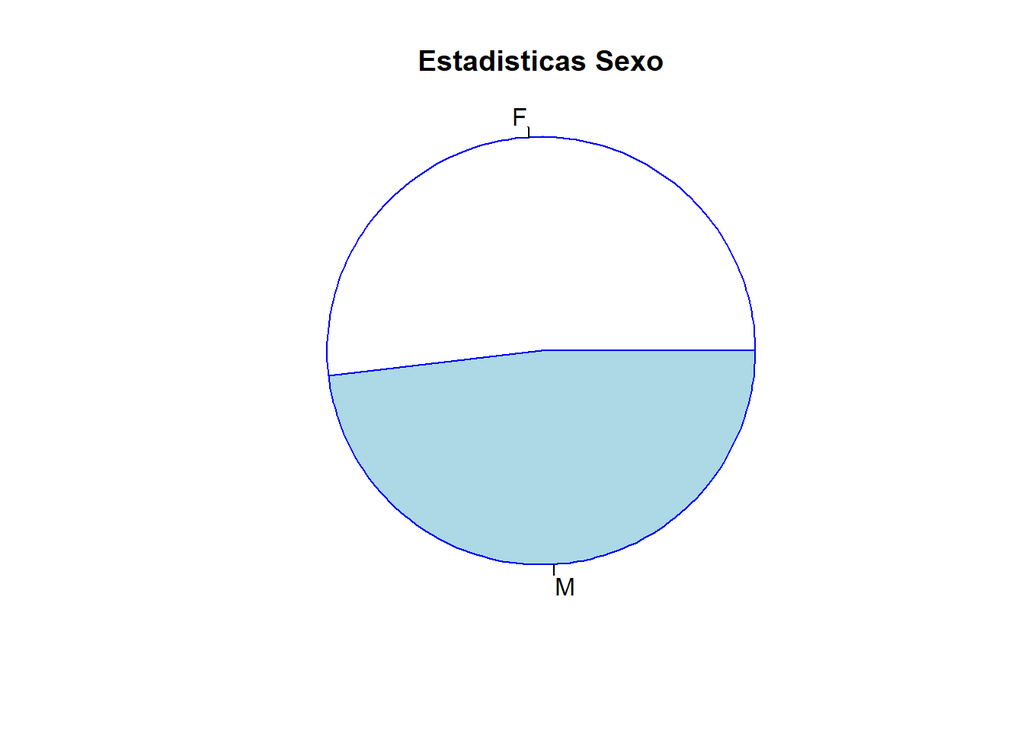

Como observamos en esta gráfica “de pie”, podemos ver que hay más chicas que chicos cursando estas asignaturas.

## Análisis de las notas

A continuación, se muestra un análisis de las notas finales, ofreciendo el número de aprobados y suspensos de chicas respecto a chicos.

```
## # A tibble: 2 x 3
##   sex    Pass  Fail
##   <fct> <dbl> <dbl>
## 1 F       123    75
## 2 M       132    52
```

Para una correcta y mejor visualización:

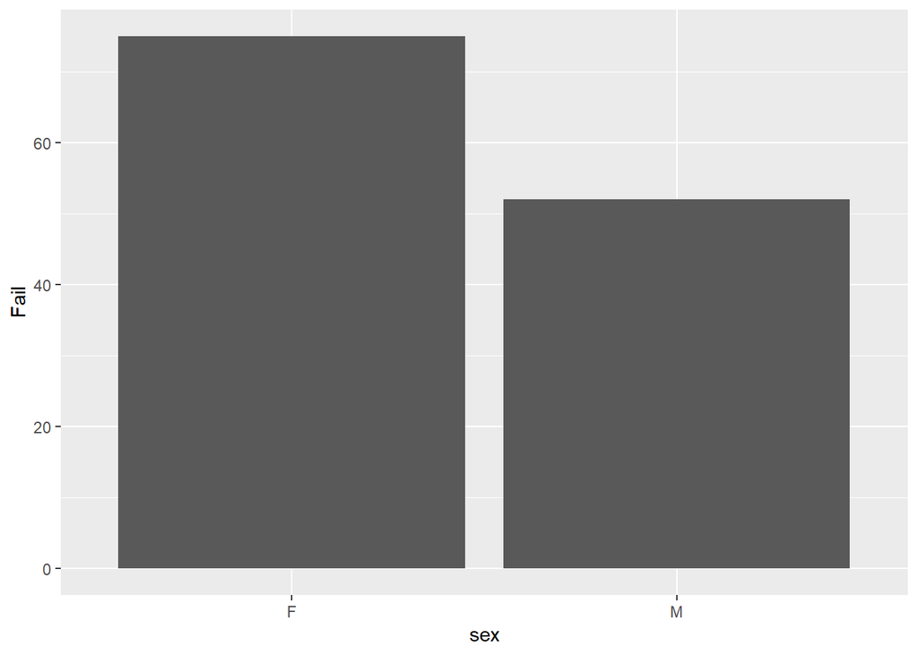

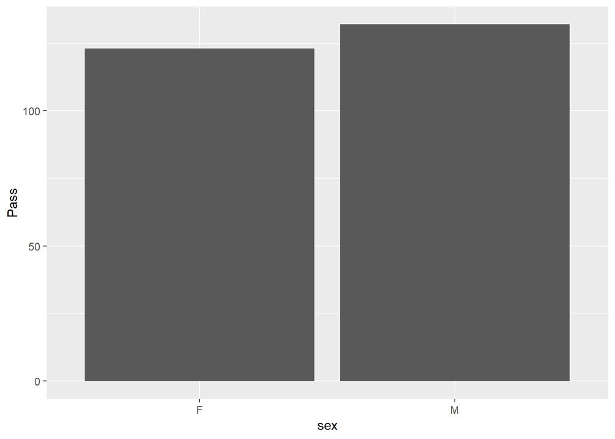

A continuación, se ofrece de forma parcial la cabecera de la tabla; para su completa visualización se exportará dicha tabla a un fichero.

```
##   school sex age Pstatus Medu Fedu internet G1.x G2.x G3.x G1.y G2.y G3.y
## 1     GP   F  15       T    1    1      yes    7   10   10   13   13   13
## 2     GP   F  15       T    1    1      yes    8    6    5   13   11   11
## 3     GP   F  15       T    2    2       no   14   13   13   14   13   12
## 4     GP   F  15       T    2    4      yes   10    9    8   10   11   10
## 5     GP   F  15       T    3    3      yes   10   10   10   13   13   13
## 6     GP   F  15       T    3    4      yes   12   12   11   11   12   12
##   media_math media_port
## 1          7         13
## 2          8         13
## 3         14         14
## 4         10         10
## 5         10         13
## 6         12         11
```

## Conclusiones:

Análisis del problema:

Observamos que algunas variables están ligadas unas con las otras y, que, no se muestra una visualización significativa en la predicción de las calificaciones. Hemos realizado diferentes interpretaciones tabulares y visuales cuyo objetivo ha sido analizar la relación entre las diferentes variables que influyen en el estudiante. Además, hemos observado que la calificación total no es sobre 10 como puede ser la estándar, sino que es sobre 20; por lo que para comprobar que un alumno está aprobado o suspenso sería el 10.

Metodología empleada:

-El análisis exploratorio simple empleado sirve para formatear los datos con el fin de adquirir los predictores y resultados que hemos presentado en las tablas. -Se utilizan visualizaciones de las tablas con el fin de comprender el análisis realizado.

Aportaciones:

Fundamentándonos en el análisis por sexo, hemos podido comprobar que las alumnas tienden a fallar en el examen final(g3) en comparación con los alumnos.